# Análisis Inteligente de Datos Trabajo Práctico N° 1 1° C 2023

```r
library(dplyr)
library(readxl)
library(psych)
library(moments)
library(ggplot2)
require(readxl)
library(stats)
library(car)
library(knitr)
library(magrittr)
```

### 1.

**Para la base de datos seleccionada genere una muestra aleatoria estratificada balanceada por “depósito” de tamaño n = 2000 utilizando como semilla los últimos tres dígitos del DNI/PASAPORTE. Guarde los datos en un archivo y realice todo el trabajo práctico con la muestra generada.práctico con la muestra generada.**

Se cargan los datos de la base de datos seleccionada en R

```r
datos <- read.csv("data.csv",sep=',')
```

Mi DNI es 40.009.997 por ende se establece 997 como seed

```r
set.seed(997)
```

Se crea una muestra estratificada de n=2000

```r
muestra <- datos %>%
  group_by(deposit) %>%
  sample_n(1000)
```

Se verifica que la muestra esté balanceada por deposito

```r
table(muestra$deposit)
```

```
##
##   no  yes
## 1000 1000
```

Se Guarda internamente la muestra con extesión csv

```r
write.csv(muestra, "muestra.csv", row.names=F)
```

### 2.

**Realice un análisis estadístico de cada una de las variables numéricas para cada valor de depósito. Presente la información en forma tabular y conteniendo las siguientes medidas descriptivas: Cantidad de datos, mínimo, máximo, media, mediana, moda, varianza, desviación estándar, coeficiente de variación, cuartil 1, cuartil 3, rango intercuartílico, MAD, asimetría, curtosis.**

```r
muestra <- read.csv("muestra.csv",sep=',')


#Agrupar los datos por depósit y resumir las estadísticas descriptivas para cada variable numérica
datos_num <- as.data.frame(select_if(muestra, is.numeric) %>%
                             mutate(deposit = muestra$deposit))

resumen_dep <- datos_num %>%
  group_by(deposit) %>%
  summarise(across(where(is.numeric), list(n = ~n(),
                                           min = ~min(.),
                                           max = ~max(.),
                                           mean = ~mean(.),
                                           median = ~median(.),
                                           mode = ~names(which.max(table(.))),
                                           var = ~var(.),
                                           sd = ~sd(.),
                                           cv = ~sd(.)/mean(.),
                                           q1 = ~quantile(., 0.25),
                                           q3 = ~quantile(., 0.75),
                                           iqr = ~IQR(.),
                                           mad = ~mad(.),
                                           skew = ~moments::skewness(.),
                                           kurt = ~moments::kurtosis(.) - 3)))


kable(resumen_dep)
```

| deposit | age_n | age_min | age_max | age_mean | age_median | age_mode | age_var | age_sd | age_cv | age_q1 | age_q3 | age_iqr | age_mad | age_skew | age_kurt | balance_n | balance_min | balance_max | balance_mean | balance_median | balance_mode | balance_var | balance_sd | balance_cv | balance_q1 | balance_q3 | balance_iqr | balance_mad | balance_skew | … |
| --- | --- | --- | --- | --- | --- | --- | --- | --- | --- | --- | --- | --- | --- | --- | --- | --- | --- | --- | --- | --- | --- | --- | --- | --- | --- | --- | --- | --- | --- | --- |
| no | 1000 | 19 | 80 | 40.930 | 39 | 34 | 108.7819 | 10.42986 | 0.2548218 | 33 | 48 | 15 | 10.3782 | 0.7020119 | 0.3129303 | 1000 | -2712 | 29207 | 1276.504 | 421 | 0 | 6975186 | 2641.058 | 2.068977 | 57.25 | 1388.0 | 1330.75 | 624.1746 | 5.122388 | … |
| yes | 1000 | 19 | 86 | 41.448 | 38 | 32 | 171.5428 | 13.09744 | 0.3159968 | 31 | 50 | 19 | 11.8608 | 0.8101103 | 0.1146221 | 1000 | -3058 | 52587 | 1912.601 | 711 | 0 | 14672696 | 3830.496 | 2.002768 | 203.50 | 2208.5 | 2005.00 | 985.9290 | 7.311996 | … |

### 3.

**Represente gráficamente cada variable numérica eligiendo el gráfico que considere apropiado. Considere la posibilidad de generar rangos de datos para su análisis y representación gráfica de las variables.**

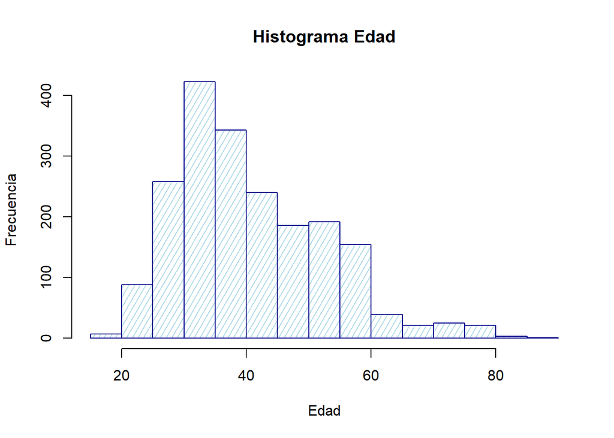

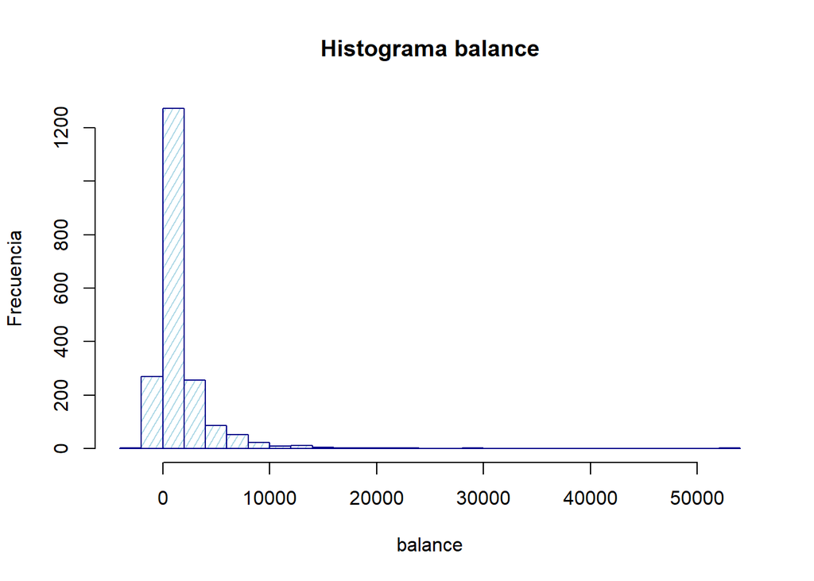

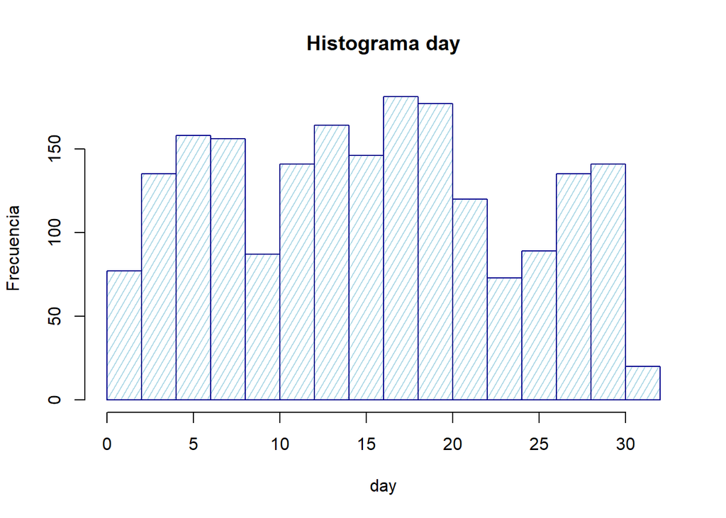

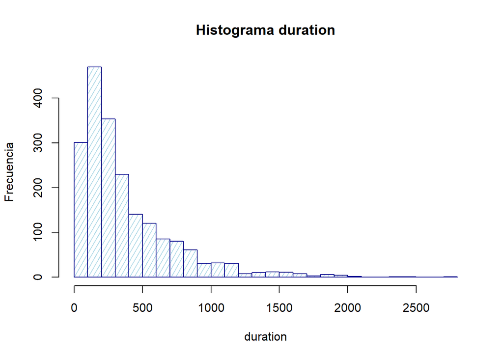

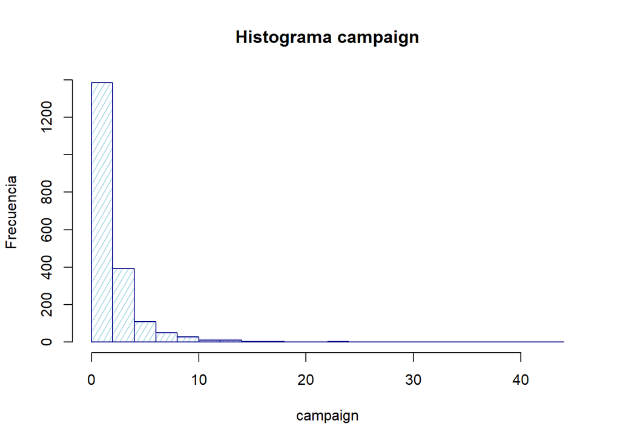

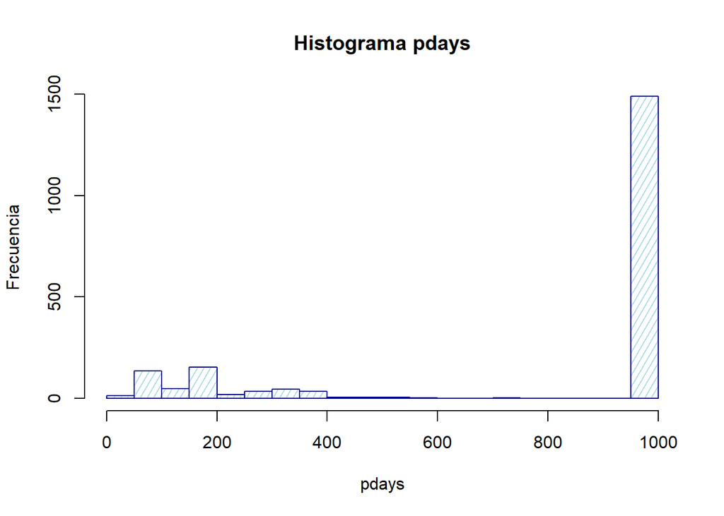

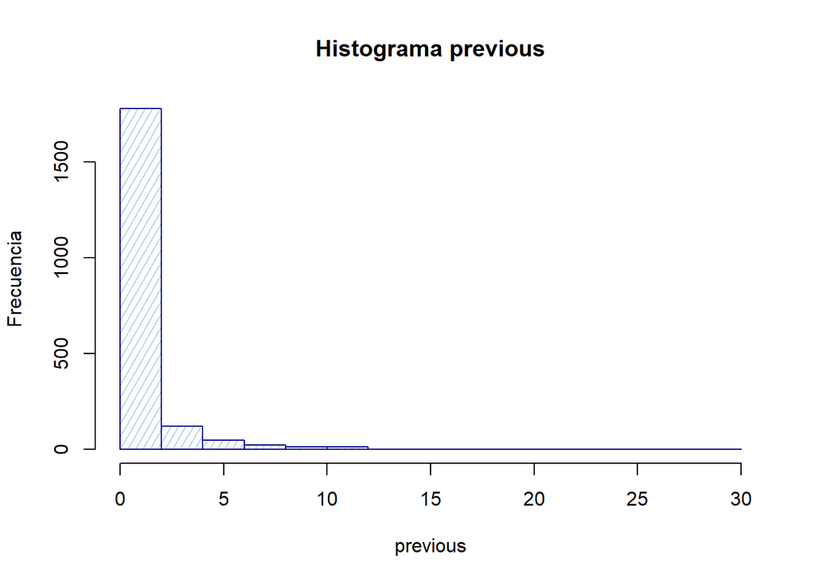

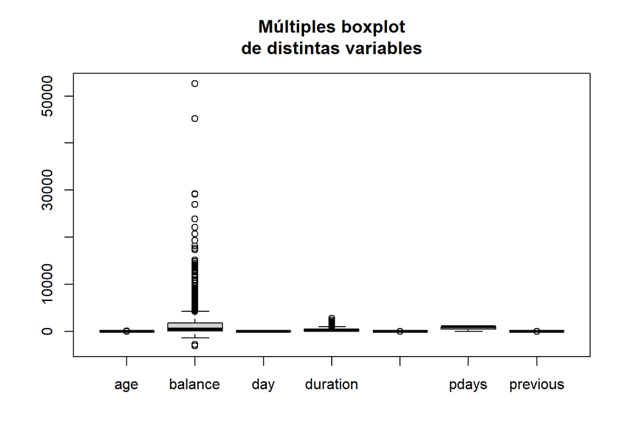

### 4.

**Presente una tabla de frecuencias y porcentaje para la variable “marital” (estado civil) según el nivel de la variable “deposit”.**

```r
# Obtener la tabla de frecuencias
tabla <- table(muestra$marital, muestra$deposit)

# Agregar los totales por fila
tabla_con_totales <- addmargins(tabla, margin = 1)
```

Tabla de frecuencias

```
##
##              no  yes
##   divorced  106  108
##   married   607  523
##   single    287  369
##   Sum      1000 1000
```

```r
# Calcular los porcentajes por fila
tabla_porcentajes <- prop.table(tabla_con_totales, margin = 1)
```

Tabla de porcentajes

```
##
##                   no       yes
##   divorced 0.4953271 0.5046729
##   married  0.5371681 0.4628319
##   single   0.4375000 0.5625000
##   Sum      0.5000000 0.5000000
```

### 5.

**Realice un gráfico para representar la tabla construida en el punto 4.**

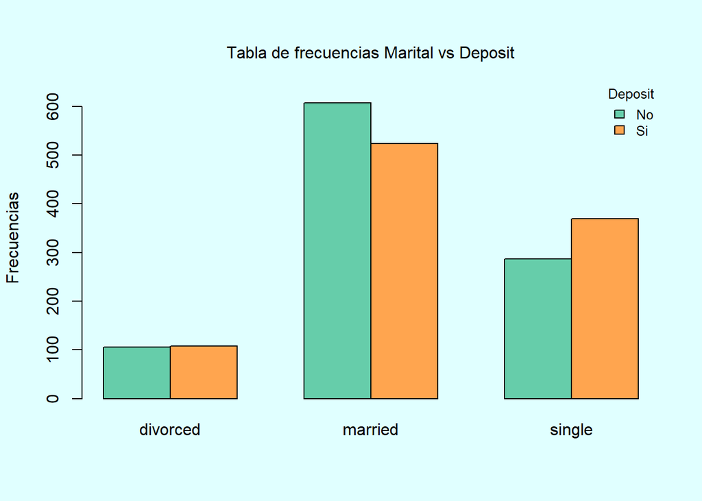

```r
# Convertir la tabla en un data frame
tabla_porcentajes_df <- as.data.frame.matrix(tabla_porcentajes)
tabla_porcentajes_df <- t(tabla_porcentajes_df[1:3,])

tabla_con_totales_df <- as.data.frame.matrix(tabla_con_totales)
tabla_con_totales_df <- t(tabla_con_totales_df[1:3,])


par(bg="lightcyan")
barplot(tabla_con_totales_df,beside=TRUE,col= c("aquamarine3","tan1"),ylim=c(0,650),ylab=" Frecuencias")
#title("Tabla de frecuencias: Marital vs Deposit",cex=0.75)
mtext("Tabla de frecuencias Marital vs Deposit",cex=1,line=1)
legend("topright",cex=0.8,title="Deposit",c("No","Si"), fill=c("aquamarine3","tan1"),horiz=F, box.lty = 0)
```

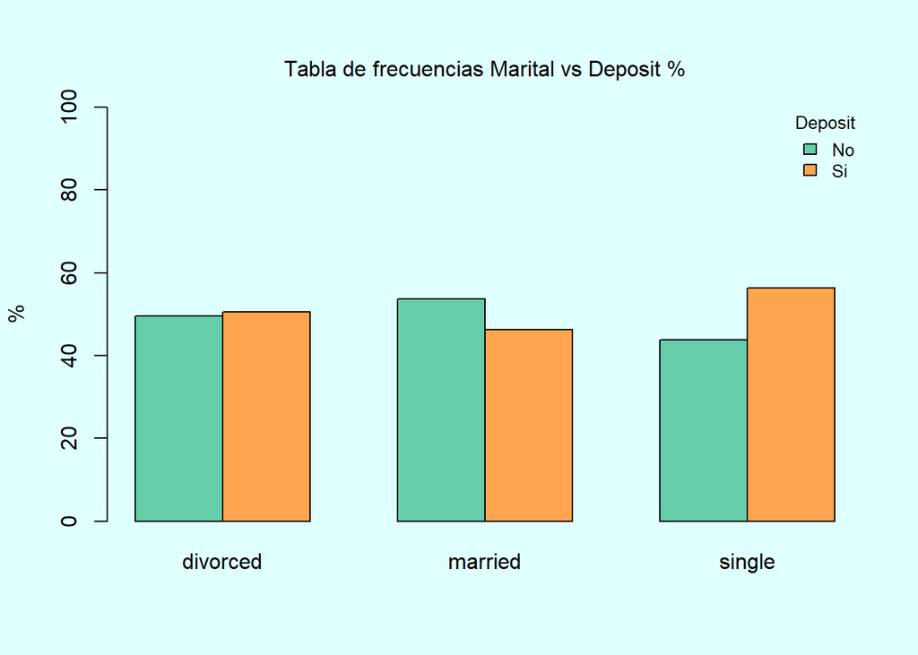

```r
par(bg="lightcyan")
barplot(tabla_porcentajes_df * 100,beside=TRUE,col= c("aquamarine3","tan1"),ylim=c(0,100),ylab="%")
#title("Tabla de frecuencias %: Marital vs Deposit",cex=0.75)
mtext("Tabla de frecuencias Marital vs Deposit %",cex=1,line=1)
legend("topright",cex=0.8,title="Deposit",c("No","Si"), fill=c("aquamarine3","tan1"),horiz=F, box.lty = 0)
```

### 6.

**Elija dos variables numericas, establezca rangos que representen distintos niveles de cada una y defina nuevas variables categóricas. Aplique un test adecuado para entender si existe asociación entre ambas. Utilice un nivel de significación del 5%.**

Se eligen las variables Age y Balance y se las discretiza de la siguiente manera:  
Age:  
* < 30: Joven  
* 30 < x < 60 Adulto  
* > 60 Mayor

Balance:  
* < 500  
* 500 < x < 2500  
* > 2500

```r
#Discretizo la variable Age
muestra$grupo_age <- cut(muestra$age, breaks = c(0, 30, 60, Inf), labels = c("joven", "adulto", "mayor"))

#Discretizo la variable Balance
muestra$grupo_balance <- cut(muestra$balance, breaks = c(-Inf, 500, 2500, Inf), labels = c("<500", "500 < x < 2500", " > mayor"))

# Obtener la tabla de frecuencias
Age_vs_balance <- table(muestra$grupo_age, muestra$grupo_balance)

# Imprimir la tabla
print(Age_vs_balance)
```

```
##
##          <500 500 < x < 2500  > mayor
##   joven   188            116       49
##   adulto  733            517      287
##   mayor    30             40       40
```

Test Chi-Cuadrdado de Independencia  
Hipotesis  
H0: Las variables son independientes  
H1: Las variables no son independientes

```r
# Establece las caracteristicas del estudio
Xsq <- chisq.test(Age_vs_balance)

Xsq$expected
```

```
##
##              <500 500 < x < 2500  > mayor
##   joven  167.8515       118.7845   66.364
##   adulto 730.8435       517.2005  288.956
##   mayor   52.3050        37.0150   20.680
```

```r
Xsq
```

```
##
##  Pearson's Chi-squared test
##
## data:  Age_vs_balance
## X-squared = 34.849, df = 4, p-value = 4.99e-07
```

p-value = 4.99e-07 < 0,05 por lo que podemos rechazar la hipótesis nula y concluir en que las variables grupo_age y grupo_balance NO son independientes con un nivel de significación del 5%.

### 7.

**Seleccione la variable “education” y elija otra variable categórica. Aplique un test adecuado para entender si existe asociación entre ambas. Utilice un nivel de significación del 5%.**

Como segunda variable categórica se elige a la variable Housing

```r
# Obtener la tabla de frecuencias
education_vs_housing <- table(muestra$education, muestra$housing)

# Imprimir la tabla
print(education_vs_housing)
```

```
##
##              no yes
##   primary   139 117
##   secondary 424 527
##   tertiary  407 277
##   unknown    70  39
```

Test Chi-Cuadrdado de Independencia  
Hipotesis  
H0: Las variables son independientes  
H1: Las variables no son independientes

```r
# Establece las caracteristicas del estudio
Xsq <- chisq.test(education_vs_housing)

Xsq$expected
```

```
##
##                 no    yes
##   primary   133.12 122.88
##   secondary 494.52 456.48
##   tertiary  355.68 328.32
##   unknown    56.68  52.32
```

```r
Xsq
```

```
##
##  Pearson's Chi-squared test
##
## data:  education_vs_housing
## X-squared = 43.44, df = 3, p-value = 1.985e-09
```

p-value = 1.985e-09 < 0,05 por lo que podemos rechazar la hipótesis nula y concluir que las variables education y housing NO son independientes con un nivel de significación del 5%.

### 8.

**Seleccione otra variable continua y estime la diferencia de medias según el valor de la variable “deposit” con un nivel de confianza del 95%. Interprete el resultado obtenido.**

Se selecciona la variable continua Duration

```r
#duration
duration_vs_deposit <- aggregate(duration ~ deposit, data = muestra, FUN = mean)

mask_no <- duration_vs_deposit$deposit == "no"
mask_yes <- duration_vs_deposit$deposit == "yes"

dif_means <- sum(duration_vs_deposit$duration[mask_yes]) - sum(duration_vs_deposit$duration[mask_no])

dif_means
```

```
## [1] 317.125
```

Diferencia entre las medias = 317,125

Hipotesis para las varianzas poblacionales  
H0: La división entre las varianzas de las poblaciones es igual a 1  
H1: La división entre las varianzas de las poblaciones no es igual a 1

```r
var.test(duration ~ deposit, data = muestra,
         alternative = "two.sided") # es una prueba bilateral
```

```
##
##  F test to compare two variances
##
## data:  duration by deposit
## F = 0.243, num df = 999, denom df = 999, p-value < 2.2e-16
## alternative hypothesis: true ratio of variances is not equal to 1
## 95 percent confidence interval:
##  0.2146381 0.2751006
## sample estimates:
## ratio of variances
##           0.242996
```

p-value = 2.2e-16 < 0,05 por lo que podemos rechazar la hipótesis nula y concluir que las varianzas de las poblaciones no son iguales con un nivel de significación del 5%.

```r
t.test(duration ~ deposit, data = muestra,
       alternative = "two.sided",
       var.equal = F) #varianzas poblacionales iguales
```

```
##
##  Welch Two Sample t-test
##
## data:  duration by deposit
## t = -22.724, df = 1457.4, p-value < 2.2e-16
## alternative hypothesis: true difference in means between group no and group yes is not equal to 0
## 95 percent confidence interval:
##  -344.4995 -289.7505
## sample estimates:
##  mean in group no mean in group yes
##           219.088           536.213
```

Como el intervalo de confianza del test no incluye al 0 se puede afirmar que las medias de las poblaciones son difrentes con un nivel de significación del 5%.